# Human Activity Recognition - Practical Machine Learning Project

Scott Poese

July 30, 2018

```r
require(dplyr)
require(caret)
```

```r
require(ggplot2)
```

## Data Import and Wrangling

We begin by importing the data into R.

```r
if (!file.exists("pml-training.csv")) {
        fileURL <- "https://d396qusza40orc.cloudfront.net/predmachlearn/pml-training.csv"
        download.file(fileURL,destfile = "pml-training.csv")
}

training <- read.csv("pml-training.csv")

if (!file.exists("pml-training.csv")) {
        fileURL2 <- "https://d396qusza40orc.cloudfront.net/predmachlearn/pml-testing.csv"
        download.file(fileURL2,destfile="pml-testing.csv")
}
testing <- read.csv("pml-testing.csv")
```

Now, we check to see which of the variables are actually usable by checking which columns have NA values and excluding those.

```r
index <- 0
for (i in 1:160) {
        if (sum(is.na(testing[,i]))==0) {
                index <- c(index,i)
        }
}
index <- index[-1]
newTest <- testing[,index]
newTrain <- training[,index]

for (i in 1:60) {
        if(sum(is.na(newTrain[,i]))!=0) {
                print(i) #Check for completeness in the training set
        }
}
dim(newTest); dim(newTrain)
```

```
## [1] 20 60
```

```
## [1] 19622    60
```

We can see that there are 60 columns left to work with, and that none of the remaining values have any NA values.

In the original paper written on exploring the dataset, the authors mention that they used 17 different features, some of which are not explicitly measured. So let’s try using the features that **do** exist in the dataset. Namely, roll_belt, total_accel_belt, total_accel_arm, total_accel_dumbbell, and pitch_forearm.

```r
trainFit <- newTrain[,c(8,11,24,37,48,60)]
testFit <- newTest[,c(8,11,24,37,48,60)]
```

## Exploratory Data Analysis

Let’s look at some of the variables the authors used and see how well they break up the activities. We look at violin plots to see if they might be able to accurately pick out a single class of activity.

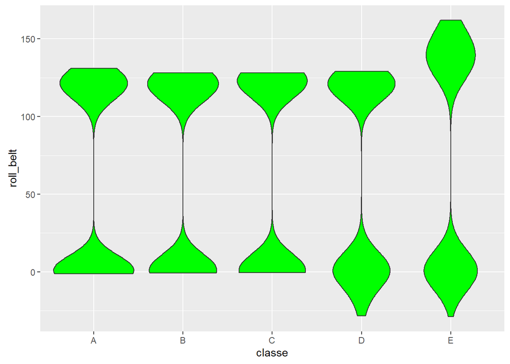

```r
ggplot(newTrain,aes(x=classe,y=roll_belt)) + geom_violin(fill="green")
```

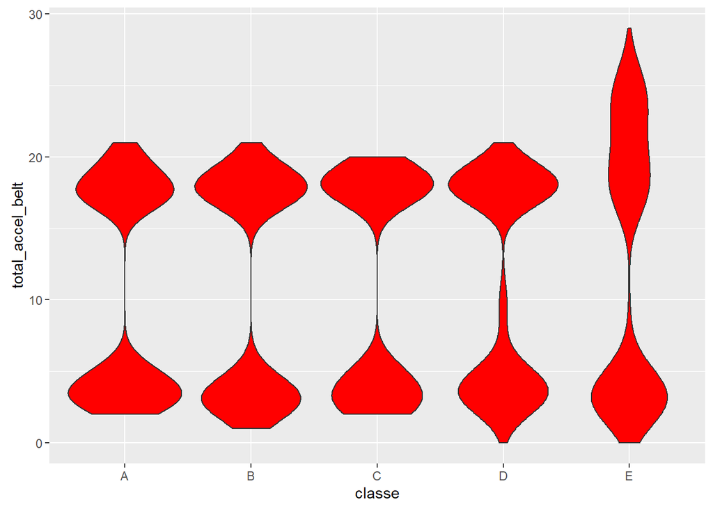

```r
ggplot(newTrain,aes(x=classe,y=total_accel_belt)) + geom_violin(fill="red")
```

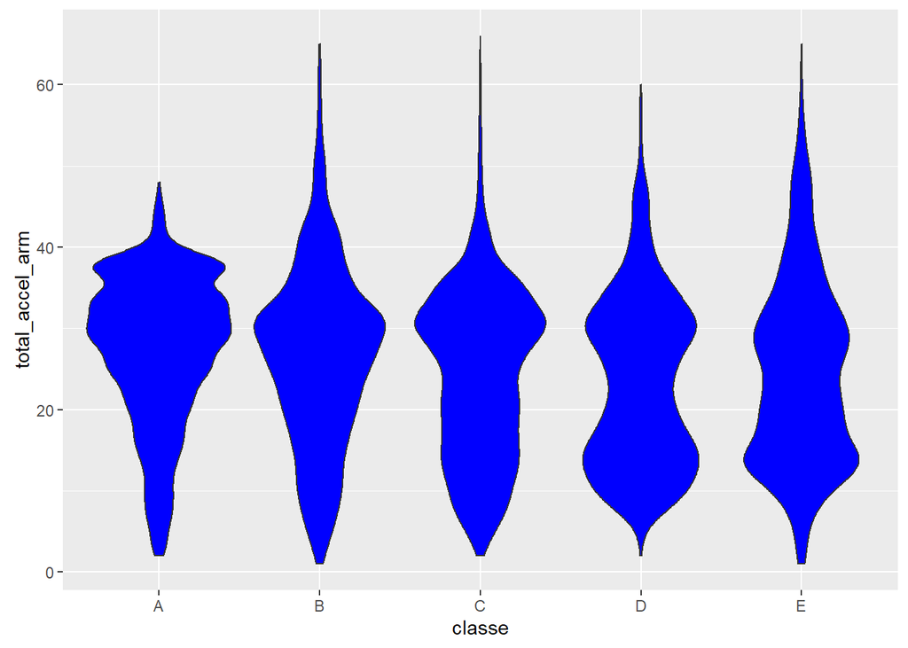

```r
ggplot(newTrain,aes(x=classe,y=total_accel_arm)) + geom_violin(fill="blue")
```

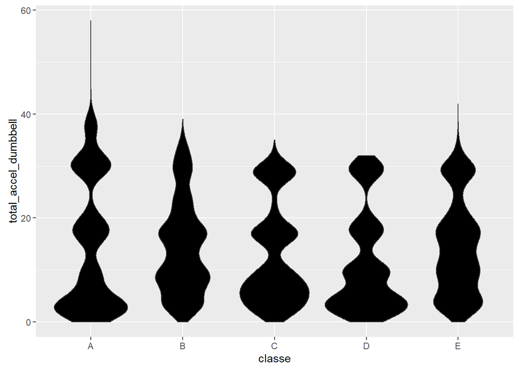

```r
ggplot(newTrain,aes(x=classe,y=total_accel_dumbbell)) + geom_violin(fill="black")
```

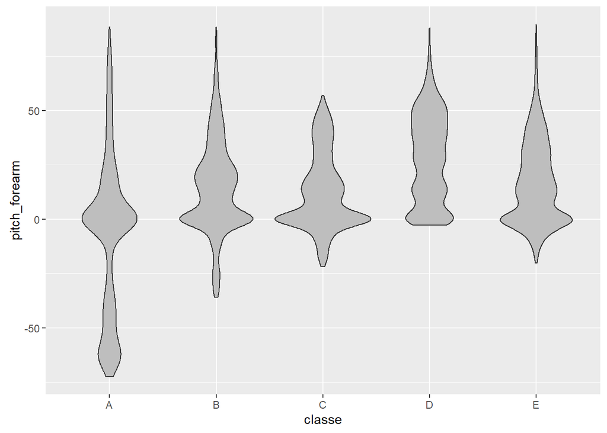

```r
ggplot(newTrain,aes(x=classe,y=pitch_forearm)) + geom_violin(fill="grey")
```

It seems that while some of the classes look similar in a single variable, the combination of them should be able to do a decent job of picking them out.

## Model Fitting

So let’s fit our model to a random forest with repeated 3-fold cross validation.

```r
modFit <- train(classe ~ ., data = trainFit, method = "rf",
                trControl = trainControl(method="repeatedcv",number=3,repeats=3))
```

We can look at the confusion matrix for the model to see it’s in-sample accuracy rate and the model as a whole to see our estimate for our out-of-sample error rate.

```r
modFit$finalModel
```

```
##
## Call:
##  randomForest(x = x, y = y, mtry = param$mtry)
##                Type of random forest: classification
##                      Number of trees: 500
## No. of variables tried at each split: 2
##
##         OOB estimate of  error rate: 11.35%
## Confusion matrix:
##      A    B    C    D    E class.error
## A 5098  182  166  121   13  0.08637993
## B  213 3119  261  163   41  0.17856202
## C  137  227 2852  190   16  0.16656926
## D  126   93  112 2863   22  0.10976368
## E   17   64   19   45 3462  0.04019961
```

With an error rate of about 11.35%, we would expect our out-of-sample rate to be slightly higher, perhaps 15-20%.

## Results

```r
predict(modFit,testFit)
```

```
##  [1] B A B A A E D B A A A C B A E E A B B B
## Levels: A B C D E
```